# DESeq Analysis of U2AF1, U2AF2, SF1

Author

Kim Nguyen

Published

July 7, 2025

# 1 Introduction

## 1.1 Background information

This practical course (F2/ 3-month internship) is aimed to investigate the role of trans-acting RNA splicing factors in the regulation of alternative splicing, and how their dysfunction can contribute to cancer and tumor growth. The project begins by exploring the fundamental mechanisms of splicing, particularly the involvement of key trans-factors such as U2AF2, U2AF1, and SF1. These proteins play crucial roles in recognizing the 3′ splice site (AG), facilitating exon definition, and promoting lariat formation during intron removal, ultimately contributing to the production of mature mRNA.

## 1.2 Objectives / Research Questions

Learning objectives: - Idenitfy key significantly regulated genes and their expression patterns. - Analyze relationships between DEG statistics. - Understand functional gene associations using Gene Ontology terms (enrichGO and g:GOST) - Explore functional correlation among splice factors * Hypotheses: - Gene expression and Splicing interaction networks are changed upon knockdown of U2AF2, U2AF1, and SF1 leading to changes in their functional enrichment.

## 1.3 Significance of the Study

Alternative splicing plays a critical role in gene regulation and has been widely implicated in cancer development. This analysis is further researching how the splicing factors, particularly 3 genes of interest (U2AF1, U2AF2, and SF1), influences revealing insight into oncogenic process and potential therapeutic targets.

### 1.3.1 Data Sources

For this study, publicly raw RNA-seq datasets (fastq files) were obtained from the ENCODE project, which are silienced or reduced the expression using short hairpin RNA (shRNA) targeting U2AF2, U2AF1, and SF1 in the HepG2 liver cancer cell line (originating from a 15-year-old white male donor). Both shRNA-treated and control samples are replicated isogenic (that are genetically identical) which help reduce variability and makes it easier to attribute observed differences.

The data analysis pipeline includes several key steps: ### Data Preprocessing and tools (version number) - quality control using FastQC and MultiQC - adapter trimming with Trimmomatic - read alignment to the reference genome using STAR aligner - quantification of gene expression with HTSeq-count - visualization of mapped reads using IGV genome browser.

# 2 Input

- Library input

```r
# For Plotting & Visualization
library(ggplot2)
library(tidyverse)
library(plotly)
library(RColorBrewer)
library(ggrepel)
library(markdown)
library(ggrastr)
library(ggpointdensity)
library(magrittr)
library(dplyr)
library(gridExtra)
library(magrittr)
library(magick)
library(RColorBrewer)
library(colorRamp2)
library(ggvenn)
library(kableExtra)
library(shadowtext)
library(eulerr)
library(UpSetR)
library(ggshadow)
library(ggforce)
library(ggpp)
library(ggsankey)
library(networkD3)
library(ggalluvial)
library(ggforce)
library(tidyr)
library(corrplot)
library(Polychrome)

# For analysis
library(pheatmap)
library(ComplexHeatmap)
library(pcaExplorer) #interactive tool for exploring PCA
library(DESeq2)
library(gprofiler2)
library(clusterProfiler)
library(enrichplot)

# annotated human genome
library(org.Hs.eg.db)
library(AnnotationDbi)
library(Homo.sapiens)

#to combine multiple ggplot
library(patchwork)
library(reshape2)
library(ggpubr)

#outpath for all results of DESeq2 analysis
mydir = "/Users/tinkienoob/Master_thesis/HepG2_DESeq_analysis"
```

- Load result from another documents

```r
load("/Users/tinkienoob/Master_thesis/HepG2_DESeq_analysis/all_results_df_DESeq2.RData")
load("/Users/tinkienoob/Master_thesis/HepG2_DESeq_analysis/gene_anno.RData")

# Create a list of dds result of each pair of KD and control
res_list = list(U2AF1 = res_U2AF1.df, U2AF2 = res_U2AF2.df, SF1 = res_SF1.df)
```

## 2.1 Splicing annotation - Core spliceosome components input

Input annotation file collected from paper: https://www.science.org/doi/10.1126/science.adn8105 (Malgorzata E. Rogalska et al. ,Transcriptome-wide splicing network reveals specialized regulatory functions of the core spliceosome.Science386,551-560(2024).DOI:10.1126/science.adn8105) which contain gene names and geneID of core spliceosome components (from both major and minor spliceosomes) and associated factors, RNA binding proteins with known regulatory functions in AS, , and RNA-modifying enzymes and chromatin-related factors linked to splicing regulation.

# 3 Differential Expression / Functional and Splicing Analysis using R studio

The primary goal is to identify genes/transcripts whose expression levels significantly differ between knockdown and control conditions. The changes in regulation interpret the biological impact of interested splicing factor depletion. https://bioconductor.org/packages/devel/bioc/manuals/DESeq2/man/DESeq2.pdf

## 3.1 Volcano plot of each KD dataset

Volcano plot is used to evaluate differential expression of genes in statistics way, Log2FoldChange cutoff is set to larger than 1 which is actual fold change equal to 2 and threshold for padj is < 0.05 that filter only significantly differential expressed genes. - LFC > 1: This means the gene’s expression is 2 times higher in the test condition compared to the control. By that, most upregulated or downregulated genes are shown on Volcano plot and enriched by GO enirchment to investigate biological processes those genes involved in. Each KDs might cause indirect or direct effects on different biological processes.

Volcano plot also uses a corrected version of padj (adjusted p-value) is to handle extreme values of -log10(padj) that would otherwise distort the plot. In other words, significant adjusted p-values are usually extremely small, therefore, -log10(padj) is used to transform the padj into the larger positive values which is easier to visualize. The smaller padj values, the higher -log10(padj) value, the more significant.

The question have been raising is that Differential expression of those genes is directly or indirectly affected by KD genes? Direct effects is when loss or change in function of SF might change pre-mRNA leading to formation of different isoform proteins (AUTOREGULATION) or instability of mRNA then nonsense mediated decay (NMD) via inclusion of premature termination codons. Whereas, in indirect effects, other SF genes in complex splicing network (secondary SFs) might involve that change gene expression or downstream regulation via alternative splicing (CROSS-regulation).

Rogalska, M. E., Mancini, E., Bonnal, S., Gohr, A., Dunyak, B. M., Arecco, N., … & Valcárcel, J. (2024). Transcriptome-wide splicing network reveals specialized regulatory functions of the core spliceosome. Science, 386(6721), 551-560.

**U2AF1 dataset**

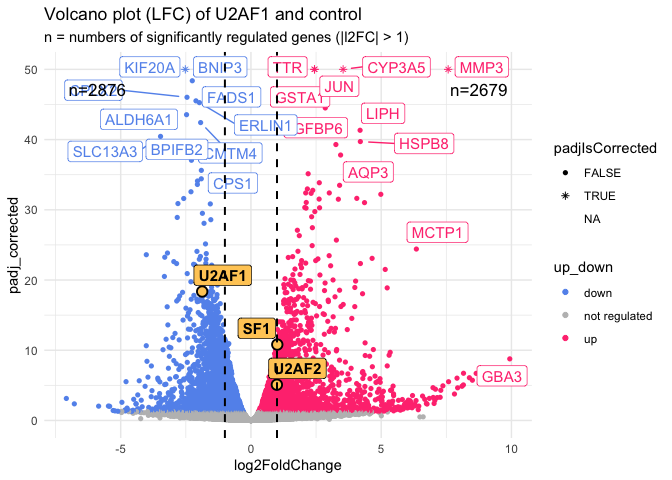

```r
#-log10(120) = -2.079181
# convert small padj into larger -log10(padj) value and padjIsCorrected ~ 50 is used to scale up the value for better visualization
volcano_U2AF1.df = dplyr::mutate(res_U2AF1.df,
                      padjIsCorrected = -log10(padj) > 50, # If -log10(padj) is greater than 50, mark it as TRUE.
                      padj_corrected = case_when(
                        padjIsCorrected ~ 50,
                        TRUE ~ -log10(padj)
                      ))

# Volcano plot of U2AF1
ggplot(volcano_U2AF1.df, aes(x= log2FoldChange, y= padj_corrected, shape= padjIsCorrected, color= up_down, label= SYMBOL)) +
  geom_point() +
  geom_point(data = subset(volcano_U2AF1.df, !is.na(myLabel)),
             fill = "#FFCC65FF", color = "black", size = 3, shape = 21, stroke = 1) +
  geom_label_repel(data = subset(volcano_U2AF1.df, !is.na(myLabel)),
                   aes(x = log2FoldChange,
                       y = padj_corrected,
                       label = SYMBOL,
                       fontface = "bold"),
                   color = "black",
                   fill = "#FFCC65FF",
                   size = 4,
                   show.legend = FALSE) +
  scale_color_manual(values= c("up" = "#FF3D7FFF", "down" = "cornflowerblue", "not regulated" = "grey")) +
  geom_label_repel(data = subset(volcano_U2AF1.df, abs(log2FoldChange) > 1), # Label genes with significant LFC (up regulation and downregulation)
                   aes(x = log2FoldChange,
                       y = padj_corrected,
                       label = SYMBOL),
                   point.padding = 0.7,
                   max.overlaps = 10,
                   size = 4,
                   show.legend = FALSE) +
  theme_minimal() +
  labs(title = "Volcano plot (LFC) of U2AF1 and control",
       subtitle = "n = numbers of significantly regulated genes (|l2FC| > 1)") +
  scale_shape_manual(values = c("TRUE" = 8, "FALSE" = 16)) +
  geom_vline(xintercept = c(1, -1), linetype= "dashed", color = "black", size = 0.7) +
  stat_quadrant_counts(data = subset(volcano_U2AF1.df, abs(log2FoldChange) > 1), aes(label = after_stat(count.label)), size = 4.5, vjust = 2)
```

**U2AF2 dataset**

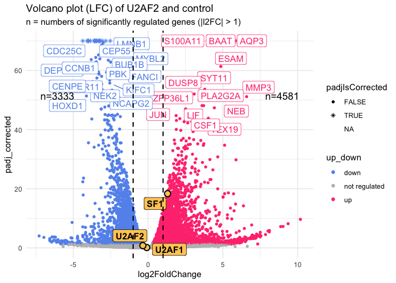

```r
# Compute -log10(padj)
volcano_U2AF2.df = dplyr::mutate(res_U2AF2.df,
                                 padjIsCorrected = -log10(padj) > 70,
                                 padj_corrected = case_when(
                                   padjIsCorrected ~ 70,
                                   TRUE ~ -log10(padj)
                                 ))
# Volcano plot
ggplot(volcano_U2AF2.df, aes(x= log2FoldChange, y= padj_corrected, shape= padjIsCorrected, color= up_down, label = SYMBOL)) +
  geom_point() +
  geom_point(data = subset(volcano_U2AF2.df, !is.na(myLabel)),
             fill = "#FFCC65FF", color = "black", size = 3, shape = 21, stroke = 1) +
  geom_label_repel(data = subset(volcano_U2AF2.df, !is.na(myLabel)), # label my label
                   aes(x = log2FoldChange,
                       y = padj_corrected,
                       label = SYMBOL,
                       fontface = "bold"),
                   color = "black",
                   fill = "#FFCC65FF",
                   point.padding = 0.5,
                   max.overlaps = 10,
                   size = 4,
                   show.legend = FALSE) +
  scale_color_manual(values= c("up" = "#FF3D7FFF", "down" = "cornflowerblue", "not regulated" = "grey")) +
  geom_label_repel(data = subset(volcano_U2AF2.df, abs(log2FoldChange) > 1), # Label genes with significant regulated genes
                   aes(x = log2FoldChange,
                       y = padj_corrected,
                       label = SYMBOL),
                   point.padding = 0.7,
                   max.overlaps = 22,
                   size = 4,
                   show.legend = FALSE) +
  theme_minimal() +
  labs(title = "Volcano plot (LFC) of U2AF2 and control",
       subtitle = "n = numbers of significantly regulated genes (|l2FC| > 1)") +
  scale_shape_manual(values = c("TRUE" = 8, "FALSE" = 16)) +
  geom_vline(xintercept = c(1, -1), linetype= "dashed", color = "black", size = 0.7) +
  stat_quadrant_counts(data = subset(volcano_U2AF2.df,
                                     abs(log2FoldChange) > 1),
                       aes(label = after_stat(count.label)),
                       size = 4.5, vjust = 8)
```

**SF1 dataset**

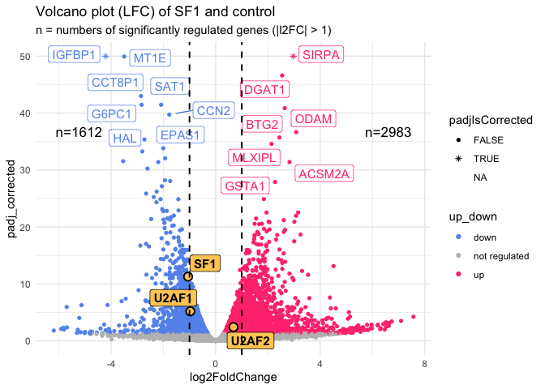

```r
# Compute -log10(adj)
volcano_SF1.df = dplyr::mutate(res_SF1.df,
                                 padjIsCorrected = -log10(padj) > 50,
                                 padj_corrected = case_when(
                                   padjIsCorrected ~ 50,
                                   TRUE ~ -log10(padj)
                                 ))

# Extract quadrant counts manually:
SF1_sigreg_quad = volcano_SF1.df %>%
  filter(abs(log2FoldChange) > 1 & padj < 0.05) %>%
  dplyr::select(c(GeneID, up_down))

# Volcano plot
ggplot(volcano_SF1.df, aes(x= log2FoldChange, y= padj_corrected,
                           shape= padjIsCorrected, color= up_down, label = SYMBOL)) +
  geom_point() +
  geom_point(data = subset(volcano_SF1.df, !is.na(myLabel)), # Label gene depletion
             fill = "#FFCC65FF", color = "black", size = 3, shape = 21, stroke = 1) +
  geom_label_repel(data = subset(volcano_SF1.df, !is.na(myLabel)),
                   aes(x = log2FoldChange,
                       y = padj_corrected,
                       label = SYMBOL,
                       fontface = "bold"),
                   color = "black",
                   fill = "#FFCC65FF",
                   point.padding = 0.5,
                   max.overlaps = 10,
                   size = 4,
                   show.legend = FALSE) +
  scale_color_manual(values= c("up" = "#FF3D7FFF", "down" = "cornflowerblue", "not regulated" = "grey")) +
  geom_label_repel(data = subset(volcano_SF1.df, abs(log2FoldChange) > 1), # Label genes with significant regulated genes
                   aes(x = log2FoldChange,
                       y = padj_corrected,
                       label = SYMBOL),
                   point.padding = 0.7,
                   max.overlaps = 10,
                   size = 4,
                   show.legend = FALSE) +
  theme_minimal() +
  labs(title = "Volcano plot (LFC) of SF1 and control",
       subtitle = "n = numbers of significantly regulated genes (|l2FC| > 1)") +
  scale_shape_manual(values = c("TRUE" = 8, "FALSE" = 16)) +
  geom_vline(xintercept = c(1, -1), linetype= "dashed", color = "black", size = 0.7) +
  stat_quadrant_counts(data = subset(volcano_SF1.df,
                                     abs(log2FoldChange) > 1),
                       aes(label = after_stat(count.label)),
                       size = 4.5, vjust = 8)
```

## 3.2 GO enrichment comparison of significantly regulated genes in each KD dataset

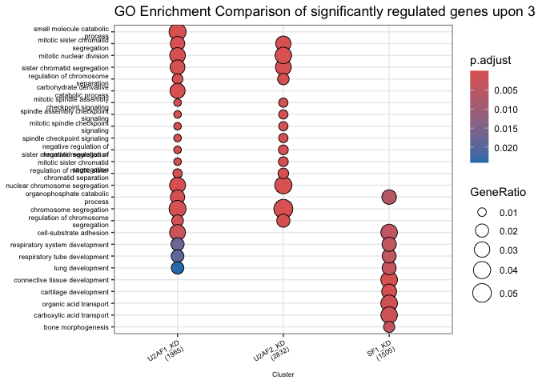

```r
U2AF1_significant_regulate = res_U2AF1.df %>%
  filter(padj < 0.05 & abs(log2FoldChange) > 1) %>%
  pull(GeneID) %>% # pull() selects a column GeneID in a data frame and transforms it into a vector.
  unique()

U2AF2_significant_regulate = res_U2AF2.df %>%
  filter(padj < 0.05 & abs(log2FoldChange) > 1) %>%
  pull(GeneID) %>% # pull() selects a column GeneID in a data frame and transforms it into a vector.
  unique() # avoid duplicate geneID

SF1_significant_regulate = res_SF1.df %>%
  filter(padj < 0.05 & abs(log2FoldChange) > 1) %>%
  pull(GeneID) %>% # pull() selects a column GeneID in a data frame and transforms it into a vector.
  unique() # avoid duplicate geneID

# Named list of gene vectors
gene_list <- list(
  U2AF1_KD = U2AF1_significant_regulate,
  U2AF2_KD = U2AF2_significant_regulate,
  SF1_KD = SF1_significant_regulate
)

# Run GO enrichment comparison
go_compare <- compareCluster(
  geneCluster = gene_list,
  keyType = "ENSEMBL",
  fun = "enrichGO",
  OrgDb = org.Hs.eg.db,
  ont = "BP", # Biological Process
  pvalueCutoff = 0.05
)

# Plot the results
dotplot(go_compare, showCategory = 10, font.size= 6.5,
        title = "GO Enrichment Comparison of significantly regulated genes upon 3 KDs") +
  theme(axis.text.x = element_text(angle = 30, hjust = 1))
```

## 3.3 Heatmap

This heatmap shows gene expression patterns across all samples (with rows representing genes and columns representing samples) to visualize co-regulated genes or differential expressed genes. Z-score is values representing how far a data point is from the mean, in units of standard deviation (sds - variation in gene expression). The result later can be used for clustering relative expression genes.

### 3.3.1 Normalization:

The count data of a particular generepresenting the number of sequence reads that reflects both gene expression and various technical factors. The higher the number of counts, the more reads associated with that gene, and the assumption that there was a higher level of expression of that gene in the sample. The counts of mapped reads for each gene is proportional to the expression of RNA (“interesting”) in addition to many other factors (“uninteresting”). Normalization is the process of scaling raw count values to account for the “uninteresting” factors. Normalization is essential to correct for these biases (e.g., sequencing depth, gene length, RNA composition), ensuring the expression levels are more comparable between and within samples and accurately reflect biological differences.

Key factors addressed during normalization: - Sequencing depth: Adjusts for varying numbers of reads per sample. - Gene length: Important for transcript-level quantification. - RNA composition: Accounts for highly expressed genes skewing the distribution. https://hbctraining.github.io/Training-modules/planning_successful_rnaseq/lessons/sample_level_QC.html

```r
dds = readRDS(paste0(mydir, "dds_DESeq2.dds"))

#Get normalized read counts of dds result
dds_count = DESeq2::counts(dds, normalized = TRUE)

#dds_count_df = as.data.frame(dds_count)

#rename rownames by remove the version of genes
rownames(dds_count) = sub("\\..*", "", rownames(dds_count))

# Convert into matrix
dds_matrix = as.matrix(dds_count)

# z-score normalization
# s1: remove rows without read counts
matrix_nozero = dds_matrix[apply(dds_matrix, MARGIN = 1, function(x)any(x!=0)), ]

#calculate z-score (pairwise distances)
# s2: calculate rowmean
rowmeans = rowMeans(matrix_nozero, na.rm = TRUE)

# s3: calculate row-wise standard deviation
sds = apply(matrix_nozero, MARGIN = 1, function(x) sd(x, na.rm = TRUE))

matrix_nozero = matrix_nozero - rowmeans # gene expression value - row mean

# s4: Z-score normalization
matrix_nozero = matrix_nozero/sds

# Replace NA value with 0
matrix_nozero[is.na(matrix_nozero)] = 0
```

Now we have a matrix (matrix_nozero) containing z-scores. Z-score normalization per gene (row), which standardizes the expression across samples (each row will have a mean ~0 and std ~1 (except for rows with constant values)).

### 3.3.2 K-means clustering calculation

The first step when using k-means clustering is to indicate the number of clusters (k) that will be generated in the final solution. The algorithm starts by randomly selecting k objects from the data set to serve as the initial centers for the clusters. The selected objects are also known as cluster means or centroids. Next, each of the remaining objects is assigned to it’s closest centroid, where closest is defined using the Euclidean distance (Eq. 1) between the object and the cluster mean. This step is called “cluster assignment step”. After the assignment step, the algorithm computes the new mean value of each cluster. The term cluster “centroid update” is used to design this step. Now that the centers have been recalculated, every observation is checked again to see if it might be closer to a different cluster. All the objects are reassigned again using the updated cluster means. The cluster assignment and centroid update steps are iteratively repeated until the cluster assignments stop changing (i.e until convergence is achieved). That is, the clusters formed in the current iteration are the same as those obtained in the previous iteration. https://uc-r.github.io/kmeans_clustering ### Column cluster by genes

```r
set.seed(123)

columncluster = kmeans(t(matrix_nozero), centers = 5, nstart = 25) # t stands for transport

# Extract and sort column cluster order
columnclusterorder = columncluster$cluster

columnclustersort = order(columnclusterorder)

# Correct diverging color palette (from blue to white to red)
#coLor = colorRamp2(c(-1, 0, 1), c("#0E54B6FF", "white", "#BD241EFF"))

coLor = colorRamp2(c(-1, 0, 1), c( "#002AFFFF",   "#FFFFFFFF", "#FF0000FF"))
```

### 3.3.3 Heatmap with different kmeans to identify best clustering

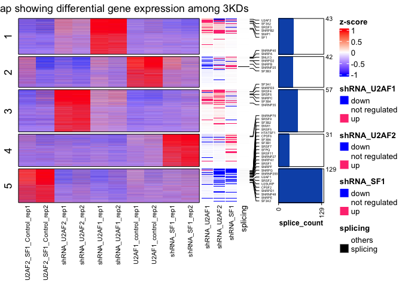

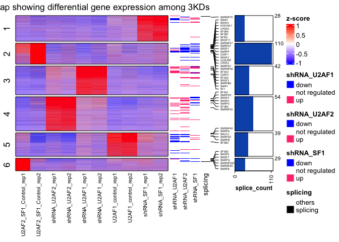

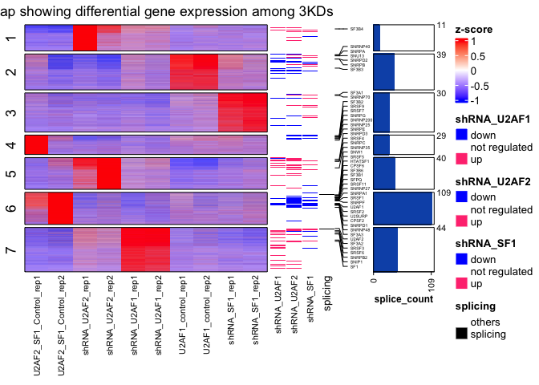

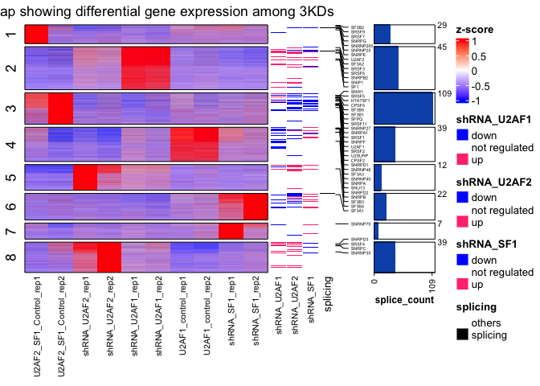

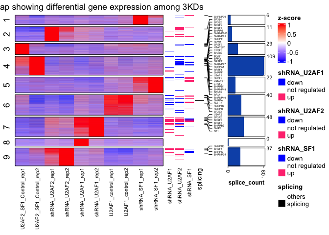

```r
# create a cluster list for later extract
cluster_list = list()
for (k in 5:9) {
  # cluster rows
  set.seed(123)

  # k-means clustering
  rowclustermatrix = kmeans(matrix_nozero, centers = k, nstart = 25)

  # assign result of kmeans to cluster list kk
  cluster_list[[paste0("k", k)]] = rowclustermatrix

  # extract the clusters
  rowclusterorder = rowclustermatrix$cluster # use $ to isolate cluster in rowclustermatrix

  # sort the rows according to the cluster
  rowclustersort = order(rowclusterorder)

  # Rearrange normalized matrix according to clustering results so similar genes/samples appear together in the heatmap.
  dds_mat = matrix_nozero[rowclustersort, columnclustersort]

  ######################### 1. Regulation annotations for each knockdown condition
  # Annotate each rows (genes) on heatmap to see whether it's upregulated, downregulated, or not regulated across different samples.
  # U2AF1
  U2AF1_anno = rowAnnotation(shRNA_U2AF1 = res_U2AF1.df$up_down[match(rownames(dds_mat),res_U2AF1.df$GeneID)],
                           col = list(shRNA_U2AF1 = c("up" = "#FF3D7FFF", "down" = "#002AFFFF", "not regulated" = NA)),
                           annotation_name_gp = gpar(fontsize = 8))
  # U2AF2
  U2AF2_anno = rowAnnotation(shRNA_U2AF2 = res_U2AF2.df$up_down[match(rownames(dds_mat),res_U2AF2.df$GeneID)],
                           col = list(shRNA_U2AF2 = c("up" = "#FF3D7FFF", "down" = "#002AFFFF", "not regulated" = NA)),
                           annotation_name_gp = gpar(fontsize = 8))
  # SF1
  SF1_anno = rowAnnotation(shRNA_SF1 = res_SF1.df$up_down[match(rownames(dds_mat),res_SF1.df$GeneID)],
                           col = list(shRNA_SF1 = c("up" = "#FF3D7FFF", "down" = "#002AFFFF", "not regulated" = NA)),
                           annotation_name_gp = gpar(fontsize = 8))

  #########################  Marking splicing-related genes (with gene labels)
  # To see which splicing-involved genes cluster the most in which row
  # 1. Create a logical vector for whether each row in dds_mat is a splicing gene
  is_splicing_gene <- ifelse(rownames(dds_mat) %in% as_anno$splice_ENSEMBL, "splicing", "others")

  # 2. Create row annotation for splicing genes
  splicing_anno <- rowAnnotation(
    splicing = is_splicing_gene,
    col = list(splicing = c("splicing" = "black", "others" = "white")),
    annotation_name_gp = gpar(fontsize = 10)
  )

  ########################## Create mark annotation for GOI
  # Add GOI column that contains U2, SR, SF in the name of genes
  as_anno = mutate(as_anno, GOI = case_when(
      grepl("U2|SF|SN", splice_SYMBOL) ~ splice_SYMBOL,
      TRUE ~ NA))

  # filter genes that is not within GOI
  as_anno_GOI = as_anno[!is.na(as_anno$GOI), ]

  # match rownames of dds matrix to ensembl of my.genes df for annotation
  anno_index = match(as_anno_GOI$splice_ENSEMBL, rownames(dds_mat))
  # remove NA value row
  anno_index = anno_index[!is.na(anno_index)]

  # label with only GOI (splicing-involved genes)
  label = as_anno_GOI$GOI

  hm_anno = rowAnnotation(foo = anno_mark(at = anno_index,
                                        labels = label,
                                        labels_gp = gpar(fontsize = 4,
                                                         font = 6), padding = unit(0.5, "mm")))

  ########################## Create bar box annotation for each row cluster
  # Extract the cluster assignments from the kmeans result
  row_split = rowclustermatrix$cluster  # numeric vector: cluster for each gene

  # Sort to match heatmap row order
  row_split = row_split[rowclustersort]

  # Ensure names match your heatmap matrix
  names(row_split) = rownames(dds_mat)

  # Identify splicing-related genes (TRUE/FALSE for each gene)
  splicing_genes_barplot <- rownames(dds_mat) %in% as_anno$splice_ENSEMBL

  # Get unique clusters (in sorted order)
  cluster_levels = sort(unique(row_split))

  # Count splicing genes per cluster
  splicing_counts = sapply(cluster_levels, function(cluster) {
    sum(splicing_genes_barplot[row_split == cluster])
  })

  # Map the cluster-wise counts to each row (gene) in the matrix
  splice_bar_values = splicing_counts[match(row_split, cluster_levels)]

  # Show label only once per cluster
  bar_labels = ifelse(!duplicated(row_split), splice_bar_values, "")

  # Barplot annotation
  ha = rowAnnotation(
    splice_count = anno_barplot(
      splice_bar_values,
      gp = gpar(col = "#0E54B6FF", fill = "#0E54B6FF"),
      bar_width = 0.8,
      width = unit(2, "cm"),
    axis_param = list(
      at = c(0, max(splice_bar_values, na.rm = TRUE)),
      labels = c("0", as.character(max(splice_bar_values, na.rm = TRUE))),
      gp = gpar(fontsize = 8)
     )
    ),
    bar_label = anno_text(
      bar_labels,
      gp = gpar(fontsize = 8),
      just = "left",
      location = 0.1),
    annotation_name_gp = gpar(fontsize = 9, fontface = "bold"), # Set the name of this label column
    annotation_name_rot = 0) # Horizontal text for title

  hm = ComplexHeatmap::Heatmap(dds_mat,
        cluster_columns = FALSE,
        cluster_rows = FALSE,
        use_raster = TRUE,
        show_row_names = FALSE,
        col = coLor,
        column_title = "Heatmap showing differential gene expression among 3KDs",
        name = "z-score",
        row_split = rowclusterorder[rowclustersort],
        border = TRUE,
        column_names_gp = gpar(fontsize=8),# change the font size of column name
        right_annotation = c(U2AF1_anno, U2AF2_anno, SF1_anno, splicing_anno, hm_anno, ha))

  print(hm)
}
```

## 3.4 Interested cluster

```r
# extract all names of genes in cluster 2 of kmean = 6
gene_cluster2_k6 = names(which(cluster_list[["k6"]]$cluster == 2))

# identify splicing genes from the extracted genes using geneID/ or ENSEMBL ID
SF_cluster2_k6 = gene_cluster2_k6[gene_cluster2_k6 %in% as_anno$splice_ENSEMBL]

# extract all names of genes in cluster 6 of kmean = 7
gene_cluster6_k7 = names(which(cluster_list[["k7"]]$cluster == 6))

# identify splicing genes from the extracted genes using geneID/ or ENSEMBL ID
SF_cluster6_k7 = gene_cluster6_k7[gene_cluster6_k7 %in% as_anno$splice_ENSEMBL]

# extract all names of genes in cluster 3 of kmean = 8
gene_cluster3_k8 = names(which(cluster_list[["k8"]]$cluster == 3))

# identify splicing genes from the extracted genes using geneID/ or ENSEMBL ID
SF_cluster3_k8 = gene_cluster3_k8[gene_cluster3_k8 %in% as_anno$splice_ENSEMBL]

SFcluster = Reduce(intersect, list(SF_cluster2_k6, SF_cluster6_k7, SF_cluster3_k8))
```

## 3.5 Functional Analysis

To gain biological inisight on the differentially expressed genes or which involved processes that are significantly up or down-regulated, genes are enriched with known biological function, interactions, or pathways. GO is divided into 3 categories: Biological Process (BP): What the gene does in the cell (e.g., DNA repair, cell cycle). Molecular Function (MF): What the gene product does at a biochemical level (e.g., ATP binding). Cellular Component (CC): Where the gene product works in the cell (e.g., nucleus, membrane).

There are different categories how genes are enriched: 1. Over-representation analysis 2. Functional Class Scoring 3. Pathway Topology Analysis GO (Gene Ontology) enrichment analysis was performed with the R package clusterProfiler (version “4.5”) (source: https://bioconductor.org/packages/release/bioc/html/clusterProfiler.html) using Over-representation analysis of a list of significant genes over a background gene list (universe).

- Inputs to ORA:
1. Significant gene list (foreground): These are the differentially expressed genes from your RNA-seq analysis (e.g., padj < 0.05).
2. Background gene list (universe): This is typically total get of genes that were tested for differential expression that passed expression and filtering thresholds.
3. Gene sets / GO terms that are pre-defined groups of genes from databases like Gene Ontology (GO)

The size of the universe (background gene list) strongly influences the outcome of GO term enrichment. The hypergeometric test looks at the proportion of DEGs overlapping with a GO term relative to the total universe size. With a smaller universe, lesser overlapping genes in a GO term are considered statistically significant in enrichment.

### 3.5.1 GO enirchment all regulated genes of specific cluster

Splicing-involved and all genes in specific cluster

```r
# Create a function to extract splicing genes from interested cluster in heatmap
genes_cluster = function(cluster_id, dds_res){

  # extract all the genes present in interested cluster
  genes_cluster = names(which(cluster_list[["k5"]]$cluster == cluster_id))

  # extract all the genes in that cluster
  all_genes_cluster = dds_res[dds_res$GeneID %in% genes_cluster,]

  # filter only regulated one
  all_reg_genes_cluster = all_genes_cluster[all_genes_cluster$regulated == TRUE,]

  # identify splicing genes from the extracted genes using geneID/ or ENSEMBL ID
  SF_genes_cluster = genes_cluster[genes_cluster %in% as_anno$splice_ENSEMBL]

  # Get SYMBOL/ gene names
  SF_genes_cluster = as_anno[as_anno$splice_ENSEMBL %in%  SF_genes_cluster,]

  # Idenitfy whether splicing genes is regulated or not and then only extract regulated ones (regulated when pvalue < 0.05 and l2FC # 0)
  SF_genes_cluster2 = dds_res[dds_res$GeneID %in%  SF_genes_cluster$splice_ENSEMBL, ]

  regulate_SF_genes = SF_genes_cluster2[SF_genes_cluster2$regulated == TRUE, ]

  regulate_SF_genes = regulate_SF_genes %>%
    dplyr::select(c(log2FoldChange, padj, GeneID, SYMBOL, regulated, up_down))

return(list(all_reg_genes_cluster = all_reg_genes_cluster, regulate_SF_genes = regulate_SF_genes))
  }
```

**U2AF2 Regulated genes**

**Cluster 5**

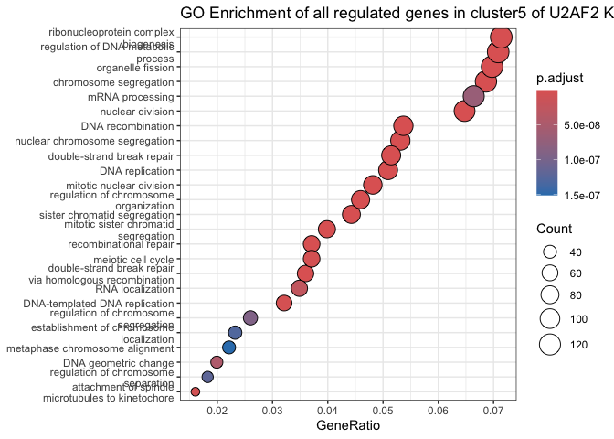

```r
######################## Cluster 5
U2AF2_cluster5 = genes_cluster(5, res_U2AF2.df)

U2AF2_cluster5_genes = U2AF2_cluster5$all_reg_genes_cluster %>%
  unique() %>% # avoid overlapping
  pull(GeneID) # extract geneid only

# GO enrich all regulated gene in cluster 5
GO_U2AF2_cluster5 = enrichGO(gene = U2AF2_cluster5_genes,
                OrgDb = org.Hs.eg.db,
                universe = res_U2AF2.df[res_U2AF2.df$baseMean > 10,]$GeneID, # the lower the baseMean, the noisier it gonna be
                keyType = "ENSEMBL",
                ont = "BP",
                pAdjustMethod = "BH",
                pvalueCutoff = 0.05,
                readable = TRUE)

# Dotplot of GO result
dotplot(GO_U2AF2_cluster5, showCategory = 25) +
  theme_bw() +
  ggtitle("GO Enrichment of all regulated genes in cluster5 of U2AF2 KD")
```

**Cluster 3**

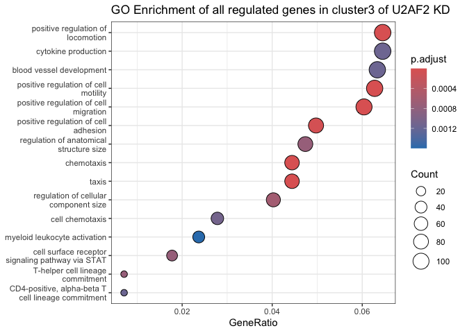

```r
U2AF2_cluster3 = genes_cluster(3, res_U2AF2.df)

U2AF2_cluster3_genes = U2AF2_cluster3$all_reg_genes_cluster %>%
  unique() %>%
  pull(GeneID)

# GO enrich all regulated gene in cluster 5
GO_U2AF2_cluster3 = enrichGO(gene = U2AF2_cluster3_genes,
                OrgDb = org.Hs.eg.db,
                universe = res_U2AF2.df[res_U2AF2.df$baseMean > 10,]$GeneID,
                keyType = "ENSEMBL",
                ont = "BP",
                pAdjustMethod = "BH",
                pvalueCutoff = 0.05,
                readable = TRUE)

# Dotplot of GO result
dotplot(GO_U2AF2_cluster3, showCategory = 15) +
  theme_bw() +
  ggtitle("GO Enrichment of all regulated genes in cluster3 of U2AF2 KD")
```

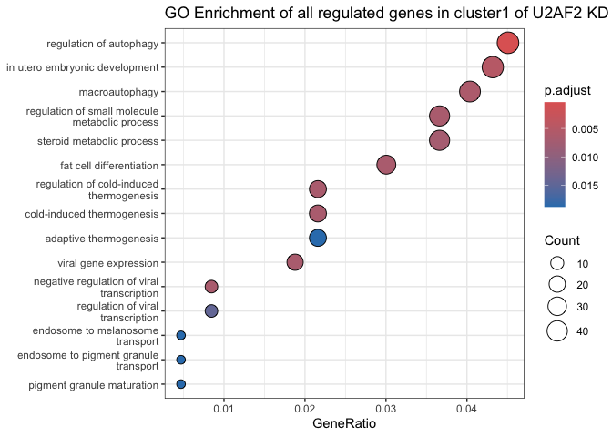

```r
U2AF2_cluster1 = genes_cluster(1, res_U2AF2.df)

U2AF2_cluster1_genes = U2AF2_cluster1$all_reg_genes_cluster %>%
  unique() %>%
  pull(GeneID)

# GO enrich all regulated gene in cluster 4
GO_U2AF2_cluster1 = enrichGO(gene = U2AF2_cluster1_genes,
                OrgDb = org.Hs.eg.db,
                keyType = "ENSEMBL",
                ont = "BP",
                pAdjustMethod = "BH",
                pvalueCutoff = 0.05,
                readable = TRUE)

# Dotplot of GO result
dotplot(GO_U2AF2_cluster1, showCategory = 15) +
  theme_bw() +
  ggtitle("GO Enrichment of all regulated genes in cluster1 of U2AF2 KD")
```

**SF1 Regulated genes**

**Cluster 4**

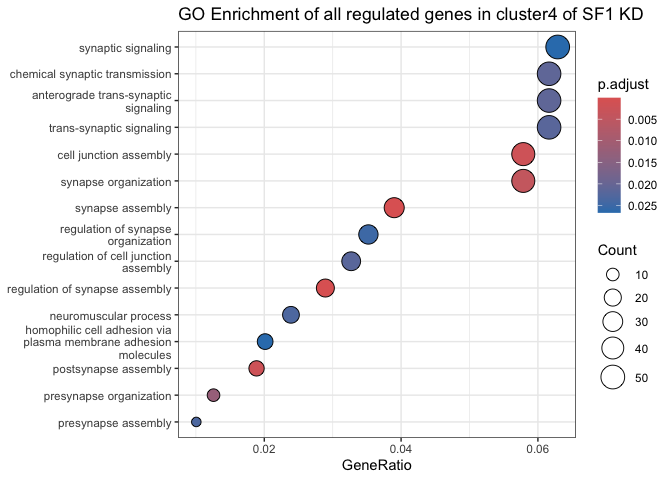

```r
SF1_cluster4 = genes_cluster(4, res_SF1.df)

SF1_cluster4_genes = SF1_cluster4$all_reg_genes_cluster %>%
  unique() %>%
  pull(GeneID)

# GO enrich all regulated gene in cluster 4
GO_SF1_cluster4 = enrichGO(gene = SF1_cluster4_genes,
                OrgDb = org.Hs.eg.db,
                universe = res_SF1.df[res_SF1.df$baseMean > 10,]$GeneID,
                keyType = "ENSEMBL",
                ont = "BP",
                pAdjustMethod = "BH",
                pvalueCutoff = 0.05,
                readable = TRUE)

# Dotplot of GO result
dotplot(GO_SF1_cluster4, showCategory = 15) +
  theme_bw() +
  ggtitle("GO Enrichment of all regulated genes in cluster4 of SF1 KD")
```

Genes in row cluster 4 may be specifically sensitive to SF1 depletion but not to U2AFs. Those genes response upregulated while SF1 KDs but down or not regulated in U2AFs KDs

**Cluster 5**

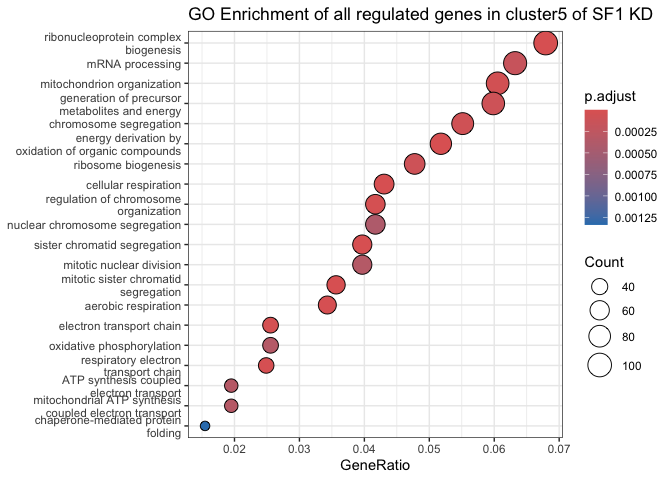

```r
SF1_cluster5 = genes_cluster(5, res_SF1.df)

SF1_cluster5_genes = SF1_cluster5$all_reg_genes_cluster %>%
  unique() %>%
  pull(GeneID)

# GO enrich all regulated gene in cluster 3
GO_SF1_cluster5 = enrichGO(gene = SF1_cluster5_genes,
                OrgDb = org.Hs.eg.db,
                universe = res_SF1.df[res_SF1.df$baseMean > 10,]$GeneID,
                keyType = "ENSEMBL",
                ont = "BP",
                pAdjustMethod = "BH",
                pvalueCutoff = 0.05,
                readable = TRUE)

# Dotplot of GO result
dotplot(GO_SF1_cluster5, showCategory = 20) +
  theme_bw() +
  ggtitle("GO Enrichment of all regulated genes in cluster5 of SF1 KD")
```

**U2AF1 Regulated genes**

**Cluster 1**

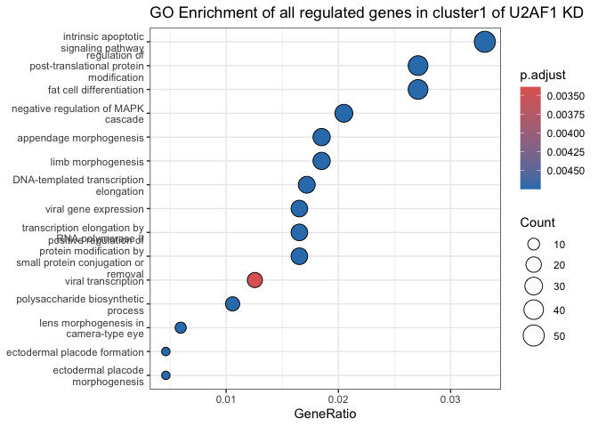

```r
U2AF1_cluster1 = genes_cluster(1, res_U2AF1.df)

U2AF1_cluster1_genes = U2AF1_cluster1$all_reg_genes_cluster %>%
  unique() %>%
  pull(GeneID)

# GO enrich all regulated gene in cluster 1
GO_U2AF1_cluster1 = enrichGO(
                gene = U2AF1_cluster1_genes,
                OrgDb = org.Hs.eg.db,
                keyType = "ENSEMBL",
                ont = "BP",
                pAdjustMethod = "BH",
                readable = TRUE)

# Dotplot of GO result
dotplot(GO_U2AF1_cluster1, showCategory = 15) +
  theme_bw() +
  ggtitle("GO Enrichment of all regulated genes in cluster1 of U2AF1 KD")
```

U2AF1 knockdown activates a distinct transcriptional program characterized by pro-apoptotic signaling, inhibition of growth-related MAPK pathways, and regulation of post-translational modification processes. These responses may reflect cellular attempts to adapt to damage arising from mis-splicing of mRNA transcripts. The presence of transcriptional and apoptotic pathway enrichment supports the idea that U2AF1 impacts both spliceosome machinery compensation and stress-adaptive and damage-responsive gene module.

Overall, U2AF1 and U2AF2 KD profiles appear more similar to each other, while SF1 KD shows more divergent expression patterns, suggesting functional overlap between U2AF1/2 and a partially distinct role for SF1.

Cluster 5 includes the highest number of regulated splicing factors (according to 305 gene names inserted from paper). Cluster row 5 highlight the KD of U2AF2 and SF1 completely change in expression pattern of genes from upregulate to downregulate, while U2AF1 KD shows a similar but slightly weaker downregulatory trend. GO enrichment for genes in this cluster reveals strong association with cell cycle–related processes, such as: Chromosome segregation Kinetochore organization DNA replication Homologous recombination and double-strand break repair => These genes may be highly sensitive to splice site disruption, and their downregulation may be due to NMD triggered by mis-splicing, or to transcriptional cascades following splicing defects. The shared trend among U2AF1/2 and SF1 suggests core splicing dependency of mitotic regulators (especially U2AF2).

In row cluster 2, U2AF1 control counts describes more expression of those genes; however, overall LFC of U2AF1 KDs vs. control showing most of genes are non- or downregulation. SF1 KD dataset presents otherwise, that some of genes, including SF3B3 gene, upregulate. Similarly to cluster 4, lots of genes including 8 splicing related genes upregulate when SF1 KD but not in U2AFs KD. This pattern reinforces the idea that SF1 uniquely regulates upward a subset of the splicing regulatory network. These may be direct targets of SF1, or indirectly upregulated due to network rewiring

Moreover, other KDs shows upregulated in row cluster 3 where U2AF2 KD dataset presents most upregulated genes. And GO terms reveal a very interesting biological effect of U2AF2 knockdown (KD). U2AF2 KD probably disrupt core splicing => directly cause mRNA degradation or indirectly altering isoforms through splicing => leading to cellular stress and then requiring cellular responses involved in cytokine signaling, cell migration or chemotaxis => relation between core spliceosome integrity and cellular stress reponse.

And in row cluster 1 in which genes of U2AF1 KD dataset are most upregulated and most expression, U2AF2 dataset also shows some upregulated genes but SF1 dataset genes are mostly neutral (nonregulated). This cluster likely contains U2AF1-specific regulatory targets or compensatory genes activated in response to its knockdown involved in stress adaptation. However, GO terms enrichment of U2AF2 and SF1 regulated genes also show completely or largely distinct biological processes. This could mean that the partial response in U2AF2 supports their interconnected regulation, while the lack of response in SF1 KD again emphasizes SF1’s distinct role.

Understanding the functional link between splice factors identified to be differentially regulated.

# 4 Regulatory genes and correlation

## 4.1 Venn diagram of regulated genes among 3KDs

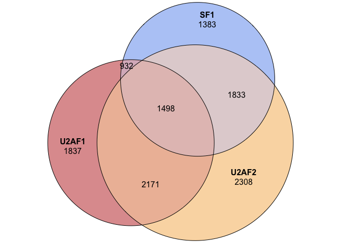

```r
# venn diagramm without size proportion to number of values
plot(eulerr::euler(regulate_gene_list),
       fills = list(fill = c("#BD241EFF", "#F5B355", "cornflowerblue"), alpha = 0.5),
       quantities = TRUE,
       stroke_size = 1, # control border size
       set_name_size = 1, # set name size
       text_size = 2)
```

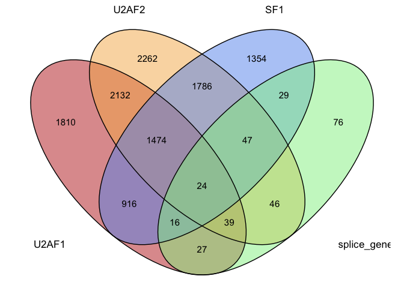

```r
ggvenn(
  c(regulate_gene_list, splice_genes = list(as_anno_genes)),
  fill_color = c("#BD241EFF", "#F5B355", "cornflowerblue", "lightgreen"),
  stroke_size = 0.5,
  set_name_size = 4.5,
  text_size = 4,
  show_percentage = FALSE
)
```

Among 3 KD datasets where GOIs are knockout to determine their roles in splicing regulation, there are common genes that are still involving in regulating gene expression. Why U2AF2 KD cause other regulating genes not change, meanwhile, U2AF2 genes still upregulats in other knockout samples. => U2AF2 is still expressing?

### 4.1.1 Scatter plot (LFC) between 2 datasets

Scatter plot of LFC is used to compare the relationship between 2 variables, here is different datasets upon KD of U2AF1, U2AF2, and SF1 genes. If correlation value (R value) is smaller than roughly 0.6, it means that 2 datasets have poor relation. In other words, genes in each dataset regulate in different direction.

The pairwise correlation of log2 fold changes (or expression changes) between datasets is used to assess how similarly two knockdowns affect gene expression. High positive R correlation means that genes tend to be regulated in the same direction in both KDs (e.g., both up or both down). On the other hand, low or negative R showing inconsistent or even opposite in direction in gene expression between KDs.

**U2AF2 and SF1**

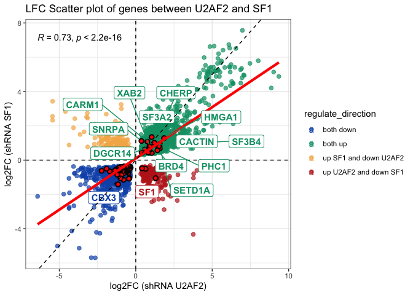

```r
# apply function on each pair of comparison
U2AF2_SF1_df = log2FC_compare(regulate_df$U2AF2, regulate_df$SF1, "U2AF2", "SF1")

ggplot(
  U2AF2_SF1_df,
  aes(x = log2FoldChangeU2AF2,
      y = log2FoldChangeSF1,
      label = splice_SYMBOL,
      color = regulate_direction)) +
  # All genes
  geom_point(aes(color = regulate_direction), size = 2, alpha = 0.7) +
  # GOI genes in black and larger
  geom_point(data = subset(U2AF2_SF1_df, !is.na(splice_SYMBOL)),
             color = "black", stroke = 1, size = 2, shape = 21, fill = "red") +
  scale_color_manual(
    values = c("both up" = "#009E73",
               "both down" = "#0E54B6FF",
               "up U2AF2 and down SF1" = "#BD241EFF",
               "up SF1 and down U2AF2" = "#F5B355"),
    na.value = "grey80") +
  geom_hline(yintercept = 0, linetype = "dashed") +
  geom_vline(xintercept = 0, linetype = "dashed") +
  geom_smooth(method = "lm", se = FALSE, color = "red", linewidth = 1.5, alpha = 0.8) +
  geom_label_repel(
    data = subset(U2AF2_SF1_df, !is.na(splice_SYMBOL)),
    aes(label = splice_SYMBOL, color = regulate_direction),
    box.padding = 0.5,
    point.padding = 0.5,
    size = 4,
    label.size = 0.3,
    max.overlaps = 80,   # how all labels regardless of overlap
    force = 1.5,           # repel force; increase if still overlapping
    force_pull = 0.7,      # pull labels toward points
    show.legend = FALSE,
    fontface = "bold") +
  geom_abline(linetype = "dashed") +
  stat_cor(aes(group =1), method = "pearson") +
  labs(
    x = "log2FC (shRNA U2AF2)",
    y = "log2FC (shRNA SF1)",
    title = "LFC Scatter plot of genes between U2AF2 and SF1") +
  theme_bw()
```

**U2AF2 and U2AF1**

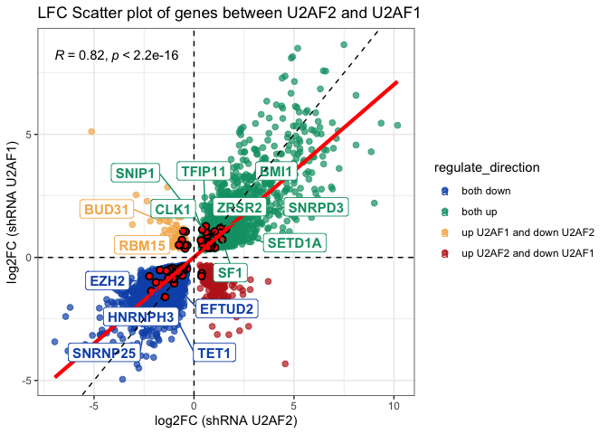

```r
# apply function on each pair of comparison
U2AF2_U2AF1_df = log2FC_compare(regulate_df$U2AF2, regulate_df$U2AF1, "U2AF2", "U2AF1")

ggplot(
  U2AF2_U2AF1_df,
  aes(x = log2FoldChangeU2AF2,
      y = log2FoldChangeU2AF1,
      label = splice_SYMBOL,
      color = regulate_direction)) +
  # All genes
  geom_point(aes(color = regulate_direction), size = 2, alpha = 0.7) +
  # GOI genes in black and larger
  geom_point(data = subset(U2AF2_U2AF1_df, !is.na(splice_SYMBOL)),
             color = "black", stroke = 1, size = 2, shape = 21, fill = "red") +
  scale_color_manual(
    values = c("both up" = "#009E73",
               "both down" = "#0E54B6FF",
               "up U2AF2 and down U2AF1" = "#BD241EFF",
               "up U2AF1 and down U2AF2" = "#F5B355"),
    na.value = "grey80") +
  geom_hline(yintercept = 0, linetype = "dashed") +
  geom_vline(xintercept = 0, linetype = "dashed") +
  geom_smooth(method = "lm", se = FALSE, color = "red", linewidth = 1.5, alpha = 0.8) +
  geom_label_repel(
    data = subset(U2AF2_U2AF1_df, !is.na(splice_SYMBOL)),
    aes(label = splice_SYMBOL, color = regulate_direction),
    box.padding = 0.5,
    point.padding = 0.5,
    size = 4,
    label.size = 0.3,
    max.overlaps = 70,   # how all labels regardless of overlap
    force = 1.5,           # repel force; increase if still overlapping
    force_pull = 0.5,      # pull labels toward points
    show.legend = FALSE,
    fontface = "bold") +
  geom_abline(linetype = "dashed") +
  stat_cor(aes(group =1), method = "pearson") +
  labs(
    x = "log2FC (shRNA U2AF2)",
    y = "log2FC (shRNA U2AF1)",
    title = "LFC Scatter plot of genes between U2AF2 and U2AF1") +
  theme_bw()
```

**U2AF1 and SF1**

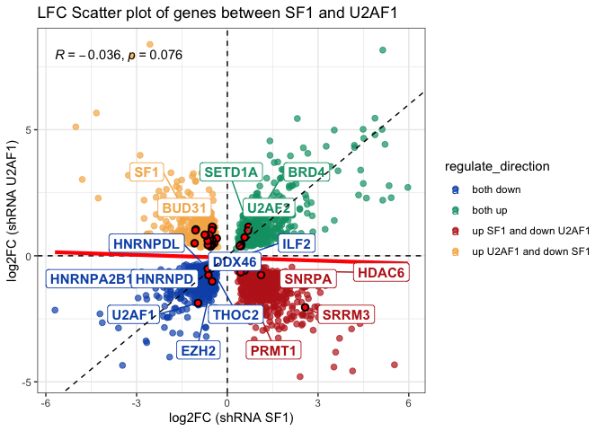

```r
SF1_U2AF1_df = log2FC_compare(regulate_df$SF1, regulate_df$U2AF1, "SF1", "U2AF1")

ggplot(
  SF1_U2AF1_df,
  aes(x = log2FoldChangeSF1,
      y = log2FoldChangeU2AF1,
      label = splice_SYMBOL,
      color = regulate_direction)) +
  # All genes
  geom_point(aes(color = regulate_direction), size = 2, alpha = 0.7) +
  # GOI genes in black and larger
  geom_point(data = subset(SF1_U2AF1_df, !is.na(splice_SYMBOL)),
             color = "black", stroke = 1, size = 2, shape = 21, fill = "red") +
  scale_color_manual(
    values = c("both up" = "#009E73",
               "both down" = "#0E54B6FF",
               "up SF1 and down U2AF1" = "#BD241EFF",
               "up U2AF1 and down SF1" = "#F5B355"),
    na.value = "grey80") +
  geom_hline(yintercept = 0, linetype = "dashed") +
  geom_vline(xintercept = 0, linetype = "dashed") +
  geom_smooth(method = "lm", se = FALSE, color = "red", linewidth = 1.5, alpha = 0.8) +
  geom_label_repel(
    data = subset(SF1_U2AF1_df, !is.na(splice_SYMBOL)),
    aes(label = splice_SYMBOL, color = regulate_direction),
    box.padding = 0.5,
    point.padding = 0.5,
    size = 4,
    label.size = 0.3,
    max.overlaps = 50,   # how all labels regardless of overlap
    force = 1.5,           # repel force; increase if still overlapping
    force_pull = 0.5,      # pull labels toward points
    show.legend = FALSE,
    fontface = "bold") +
  geom_abline(linetype = "dashed") +
  stat_cor(aes(group =1), method = "pearson") +
  labs(
    x = "log2FC (shRNA SF1)",
    y = "log2FC (shRNA U2AF1)",
    title = "LFC Scatter plot of genes between SF1 and U2AF1") +
  theme_bw()
```

As above argument, U2AF2 is a central scaffolding protein in early spliceosome assembly, directly interacting with both: U2AF1 (binds 3’ splice site AG), SF1 (binds the branch point). Therefore, knocking down U2AF2 disrupts interactions with both U2AF1 and SF1 and affects many shared downstream effects as U2AF1 and SF1 KDs. Otherwise, U2AF1 and SF1 probably regulate largely distinct or even opposite regulatory effects on transcripts or splicing. In other words, a gene that are upregulated in U2AF1 KD performing downregulation in SF1 KD and vice versa.

## 4.2 GO enrichment analysis of unique and overlapping regulated genes among 3 Kds

gProfiler2 (version 0.2.3) ### Alluvial diagram

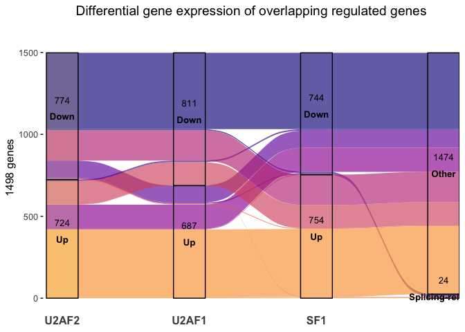

```r
# create df for alluvial diagram
alluvial_intersect_df <- merge_regulate_df %>%
  mutate(
    U2AF1 = case_when(up_down_U2AF1 == "up" ~ "Up", up_down_U2AF1 == "down" ~ "Down"),
    U2AF2 = case_when(up_down_U2AF2 == "up" ~ "Up", up_down_U2AF2 == "down" ~ "Down"),
    SF1 = case_when(up_down_SF1   == "up" ~ "Up", up_down_SF1   == "down" ~ "Down")
  ) %>%
  dplyr::select(GeneID, U2AF1, U2AF2, SF1)

alluvial_intersect_df$Splicing <- ifelse(alluvial_intersect_df$GeneID %in% as_anno$splice_ENSEMBL,
                                         "Splicing-related", "Other")

# Convert into alluvial format
alluvial_intersect_long <- as.data.frame(table(alluvial_intersect_df$U2AF1, alluvial_intersect_df$U2AF2, alluvial_intersect_df$SF1, alluvial_intersect_df$Splicing))

# Rename the column in df
colnames(alluvial_intersect_long) <- c("U2AF1", "U2AF2", "SF1", "Splicing", "Freq")

ggplot(alluvial_intersect_long,
       aes(axis1 = U2AF2,
            axis2 = U2AF1,
            axis3 = SF1,
            axis4 = Splicing,
            y = Freq)) +
  # Flow with unique color for each combination
  geom_alluvium(aes(fill = interaction(U2AF2,U2AF1,SF1)), width = 1/4, alpha = 0.65) +

  # Strata color by first variable
  geom_stratum(aes(fill = U2AF2), width = 1/4, color = "black", alpha = 0.1) +

  # Text for strata
  geom_text(stat = "stratum",
            aes(label = after_stat(stratum)),
            size = 3.5, fontface = "bold") +

  # Text for total numbers of genes in each stratum
  geom_text(stat = "stratum",
            aes(label = after_stat(count)),
            nudge_y = 100,
            size = 3.5,
            check_overlap = TRUE) +

  scale_x_discrete(limits = c("U2AF2", "U2AF1", "SF1"), expand = c(0.05, 0.05)) +
  scale_fill_viridis_d(option = "plasma", drop = FALSE) +

  labs(y = "1498 genes",
       title = "Differential gene expression of overlapping regulated genes") +

  theme_alluvial(base_size = 12) +
  theme(legend.position = "none",
        plot.title = element_text(hjust = 0.5),
        axis.text.x = element_text(face = "bold", size = 12))
```

### 4.2.1 Intersecting genes among 3 KDs

```r
# Collect geneIds intersecting among 3 data sets
intersect_genes = Reduce(intersect, list(regulate_gene_list$U2AF1,
                                         regulate_gene_list$U2AF2,
                                         regulate_gene_list$SF1))

# Count number of overlapping genes
print(paste("Number of overlapping genes among 3 KDs:", length(unique(intersect_genes)), "genes"))
```

```
[1] "Number of overlapping genes among 3 KDs: 1498 genes"
```

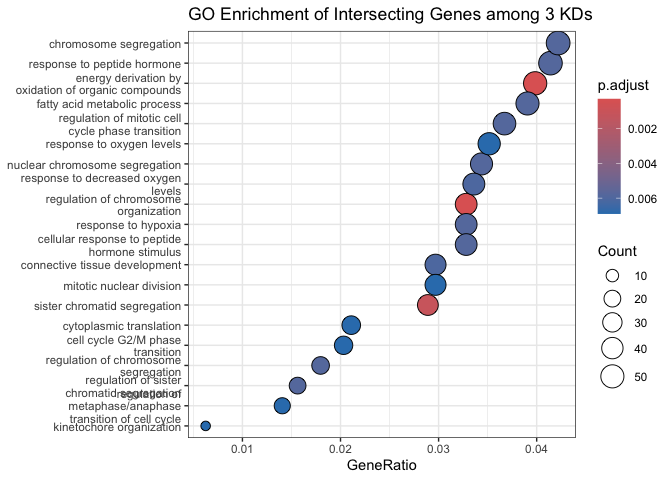

```r
# Extract up/ downregulate genes among intersecting list
intersecting_regulate_df = merge_regulate_df[merge_regulate_df$GeneID %in% intersect_genes, ]

intersecting_regulate_df = dplyr::select(intersecting_regulate_df, c(GeneID, up_down_U2AF1, up_down_U2AF2, up_down_SF1))

intersecting_regulate_df = left_join(intersecting_regulate_df, gene_anno, by = c("GeneID" = "ENSEMBL"))

# GO enrich
ego_intersecting_res = enrichGO(gene = intersect_genes,
                OrgDb = org.Hs.eg.db,
                keyType = "ENSEMBL",
                ont = "BP",           # or "MF", "CC"
                pAdjustMethod = "BH",
                pvalueCutoff = 0.05)

# Dotplot of GO result
dotplot(ego_intersecting_res,
        showCategory = 20,
        font.size = 7) +
  theme_bw() +
  ggtitle("GO Enrichment of Intersecting Genes among 3 KDs")
```

```r
# Filter by splicing-related GO terms by grep() multiple
#ego_intersecting_genes = ego_intersecting_res@result[grepl("segregation|chromosome|cell cycle|chromatid", ego_intersecting_res@result$Description, ignore.case = TRUE), ]

# Combine all geneIDs from selected splicing GO terms by
## unlist then split all geneID after "/"
#ego_intersecting_geneids = unique(unlist(strsplit(ego_intersecting_genes$geneID, "/")))
```

Extract all genes overlapping between 2 datasets function

```r
################################### Extract all genes overlapping between d1 and d2 datasets but not involved in d3
intersecting_d1_d2 <- function(d1, d2, d3) {
  # Extract gene lists
  genes_d1 <- regulate_gene_list[[d1]]
  genes_d2 <- regulate_gene_list[[d2]]
  genes_d3 <- regulate_gene_list[[d3]]

  # Overlap d1 and d2
  all_intersect_d1_d2 <- intersect(genes_d1, genes_d2)

  # Remove genes also found in d3
  intersect_d1_d2 <- setdiff(all_intersect_d1_d2, genes_d3)

  return(list(
    intersect_genes = intersect_d1_d2,
    intersect_number = length(unique(intersect_d1_d2))
  ))
}

intersecting_U2AF2_SF1 = intersecting_d1_d2("U2AF2", "SF1", "U2AF1")
U2AF2_intersect_SF1_res = res_list$U2AF2[res_list$U2AF2$GeneID %in% intersecting_U2AF2_SF1$intersect_genes, ]
SF1_intersect_U2AF2_res = res_list$SF1[res_list$SF1$GeneID %in% intersecting_U2AF2_SF1$intersect_genes, ]
```

## 4.3 Unique genes in U2AF2, U2AF1 or SF1

```r
## setdiff is used to  genes that are in U2AF2 but absent from both U2AF1 and SF1
## union combines the unique GeneIDs from both datasets U2AF1 and SF1
uniq_U2AF2 = regulate_gene_list$U2AF2[regulate_gene_list$U2AF2 %in%
                                        setdiff(regulate_gene_list$U2AF2,
                                                union(regulate_gene_list$U2AF1, regulate_gene_list$SF1))]
n_distinct(uniq_U2AF2)
```

```
[1] 2308
```

```r
## setdiff is used to  genes that are in U2AF1 but absent from both U2AF2 and SF1
## union combines the unique GeneIDs from both datasets U2AF2 and SF1
uniq_U2AF1 = regulate_gene_list$U2AF1[regulate_gene_list$U2AF1 %in%
                                        setdiff(regulate_gene_list$U2AF1,
                                                union(regulate_gene_list$U2AF2, regulate_gene_list$SF1))]
n_distinct(uniq_U2AF1)
```

```
[1] 1837
```

```r
## setdiff is used to  genes that are in SF1 but absent from both U2AF1 and U2AF2
## union combines the unique GeneIDs from both datasets U2AF1 and U2AF2
uniq_SF1 = regulate_gene_list$SF1[regulate_gene_list$SF1 %in%
                                        setdiff(regulate_gene_list$SF1,
                                                union(regulate_gene_list$U2AF1, regulate_gene_list$U2AF2))]
n_distinct(uniq_SF1)
```

```
[1] 1383
```

### 4.3.1 GO enrichment of unique regulated genes

**U2AF2 dataset**

https://biit.cs.ut.ee/gplink/l/avHqC_JRaSe

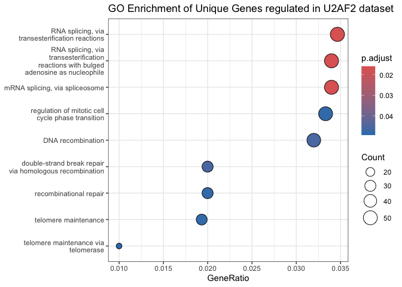

```r
# GO enrich
GO_unique_U2AF2 = enrichGO(gene = uniq_U2AF2,
                OrgDb = org.Hs.eg.db,
                keyType = "ENSEMBL",
                ont = "BP",           # or "MF", "CC"
                pAdjustMethod = "BH",
                pvalueCutoff = 0.05,
                readable = TRUE)

# Dotplot of GO result
dotplot(GO_unique_U2AF2, showCategory = 15) +
  theme_bw() +
  ggtitle("GO Enrichment of Unique Genes regulated in U2AF2 dataset")
```

```r
# Extract splicing-related genes in upregulated overlapping genes
GO_unique_U2AF2_splicing <- GO_unique_U2AF2@result %>%
  filter(grepl("splic|spliceosome|RNA process", Description, ignore.case = TRUE))

GO_unique_U2AF2_splicing_genes <- unique(unlist(strsplit(GO_unique_U2AF2_splicing$geneID, "/")))

gprofiler_unique_U2AF2 <- gost(query = uniq_U2AF2, # input geneIDs
                organism = "hsapiens", # organism of interest
                significant = TRUE, # return only the significant result
                exclude_iea = FALSE,  # do not exclude GO electronic annotation
                evcodes = TRUE, # include evidence code
                user_threshold = 0.05, # P-value threshold (eg. P value<= 0.05)
                correction_method = "g_SCS",  # Multiple testing correction method
                domain_scope = "annotated",
                as_short_link = TRUE) # domain scope
```

U2AF2 is more central in early spliceosome assembly compared to U2AF1 and SF1 which binds polypyrimidine tracts and interacts with many early splicing factors, possibly affecting splicing of other splicing regulators. Therefore, depletion of U2AF2 potentially impact on splicing regulation of other SFs and also genome stability that requires repair process (ds break repair or recombinational repair)

**U2AF1 dataset**

https://biit.cs.ut.ee/gplink/l/ahYEVuhIjQ-

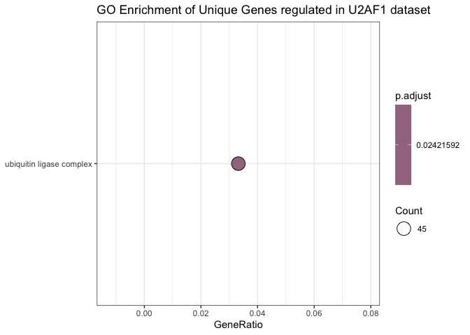

```r
# GO enrich
GO_unique_U2AF1 = enrichGO(gene = uniq_U2AF1,
                OrgDb = org.Hs.eg.db,
                keyType = "ENSEMBL",
                ont = "ALL",           # or "MF", "CC"
                pAdjustMethod = "BH",
             #   pvalueCutoff = 1,
                readable = TRUE)

# Dotplot of GO result
dotplot(GO_unique_U2AF1, showCategory = 15) +
  theme_bw() +
  ggtitle("GO Enrichment of Unique Genes regulated in U2AF1 dataset")
```

```r
gprofiler_unique_U2AF1 <- gost(query = uniq_U2AF1, # input geneIDs
                organism = "hsapiens", # organism of interest
                significant = TRUE, # return only the significant result
                exclude_iea = FALSE,  # do not exclude GO electronic annotation
                evcodes = TRUE, # include evidence code
                user_threshold = 0.05, # P-value threshold (eg. P value<= 0.05)
                correction_method = "g_SCS",  # Multiple testing correction method
                domain_scope = "annotated",
                as_short_link = TRUE) # domain scope
```

**SF1 dataset**

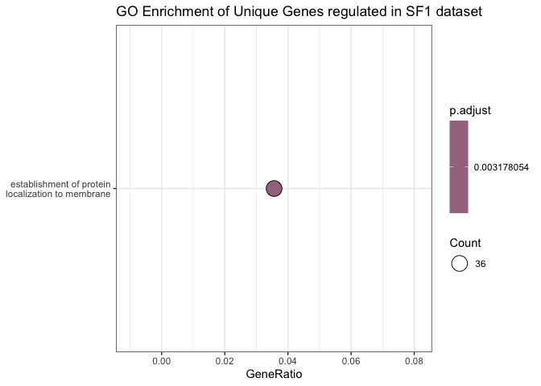

```r
# GO enrich
GO_unique_SF1 = enrichGO(gene = uniq_SF1,
                OrgDb = org.Hs.eg.db,
                keyType = "ENSEMBL",
                ont = "BP",
                pAdjustMethod = "BH",
                readable = TRUE)

# Dotplot of GO result
dotplot(GO_unique_SF1, showCategory = 15) +
  theme_bw() +
  ggtitle("GO Enrichment of Unique Genes regulated in SF1 dataset")
```

```r
gprofiler_unique_U2AF1 <- gost(query = uniq_SF1, # input geneIDs
                organism = "hsapiens", # organism of interest
                significant = TRUE, # return only the significant result
                exclude_iea = FALSE,  # do not exclude GO electronic annotation
                evcodes = TRUE, # include evidence code
                user_threshold = 0.05, # P-value threshold (eg. P value<= 0.05)
                correction_method = "g_SCS",  # Multiple testing correction method
                domain_scope = "annotated",
                as_short_link = TRUE) # domain scope
```

U2AF1 and SF1 may affect fewer differential expression genes uniquely compared to U2AF2.

# 5 Functional splice factor analysis

Aim: Understanding the functional link between splice factors identified to be differentially regulated. Steps: 1. Make a heatmap with SFs, from the Rogaslka et al., 2024, using their gene expression values after perturbation of U2AF2, U2AF1, and SF1 individually. 2. Note. Please do step 1 with different k-means clustering values to identify clusters revealing the underlying patterns. Such as SFs regulated in all, or only under specific conditions such as U2AF2 & U2AF1, U2AF1 & SF1, U2AF2 unique etc. 3. The supplement table 1 includes the categories the SFs belong to. It would be interesting to label that in the heatmap. So we know whether the SFs from certain groups are clustered together.

## 5.1 Sankey diagram

To overview regulation trend of 305 SFs across different perturbations

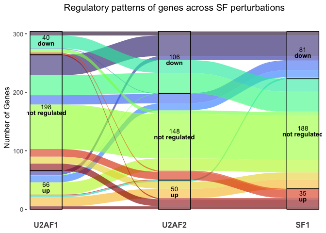

```r
SF_sankey_df = purrr::imap(res_list, function(res, condition) {

  res_sf = res[res$GeneID %in% as_anno_genes, ]

  res_sf %>%
    dplyr::select(GeneID, up_down) %>%
    mutate(Condition = condition) %>%
    rename(Regulation = up_down)
}) %>% bind_rows()

# Convert to wide format
SF_sankey_df <- SF_sankey_df %>%
  pivot_wider(names_from = Condition, values_from = Regulation)

# 1. Aggregate combinations by frequency
sankey_df_count <- SF_sankey_df %>%
  group_by(U2AF1, U2AF2, SF1) %>%
  summarise(Freq = n(), .groups = "drop")

# 2. Plot Sankey
ggplot(sankey_df_count,
       aes(axis1 = U2AF1, axis2 = U2AF2, axis3 = SF1, y = Freq)) +
  geom_alluvium(aes(fill = interaction(U2AF1, U2AF2, SF1)), width = 1/4, alpha = 0.65) +
  geom_stratum(width = 1/4, color = "black", alpha = 0.1) +
  # Text for strata
  geom_text(stat = "stratum",
            aes(label = after_stat(stratum)),
            size = 3.5, fontface = "bold") +
  # Text for total numbers of genes in each stratum
  geom_text(stat = "stratum",
            aes(label = after_stat(count)),
            nudge_y = 10,
            size = 3.5,
            check_overlap = TRUE) +
  scale_x_discrete(limits = c("U2AF1", "U2AF2", "SF1"), expand = c(0.05, 0.05)) +
  scale_fill_viridis_d(option = "turbo", drop = FALSE) +
  labs(y = "Number of Genes",
       title = "Regulatory patterns of genes across SF perturbations") +
  theme_alluvial(base_size = 12) +
  theme(legend.position = "none",
        plot.title = element_text(hjust = 0.5),
        axis.text.x = element_text(face = "bold", size = 12))
```

Prepare matrix for heatmap

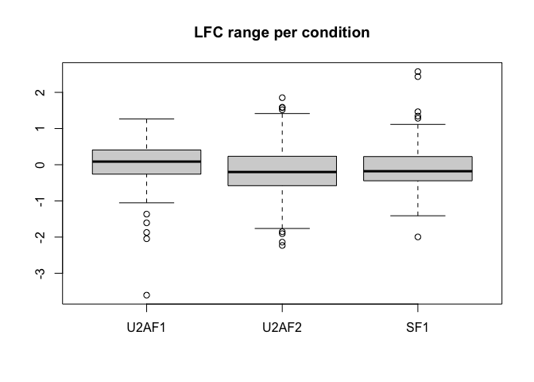

```r
SF_hm_df = purrr::imap(res_list, function(res, condition) {

  res_sf = res[res$GeneID %in% as_anno_genes, ]

  res_sf %>%
    dplyr::select(SYMBOL, log2FoldChange) %>%
    mutate(Condition = condition) %>%
    rename(LFC = log2FoldChange)
}) %>% bind_rows()

# Convert to wide format
SF_hm_df <- SF_hm_df %>%
  pivot_wider(names_from = Condition, values_from = LFC) %>%
  na.omit()

# Create splice map containing Names = splice_ENSEMBL and values = splice_SYMBOL
#splice_map = setNames(as_anno$splice_SYMBOL, as_anno$splice_ENSEMBL)

# Subset the 305 splicing genes
SF_hm_mat <- SF_hm_df %>%
  drop_na() %>% # remove rows with any NA
  column_to_rownames("SYMBOL") %>% # turn SYMBOL column into rownames
  as.matrix()

boxplot(SF_hm_mat, main = "LFC range per condition")
```